# R Notebook

Jonathan Calvopiña Merchan

17/1/2022

## 1) Generadores congruenciales

### 1.1) Generador Congruencial lineal Mixto

$$\ x_{n} =\ (ax_{n-1} + c)\ mod\ m$$

### 1.2) Generador Congruencial multiplicativo o generador de numeros pseudoaleatorios de Lehmer

$$\ x_{n} =\ (ax_{n-1})\ mod\ m$$

es cuando c = 0

Siendo :

$\ x_{n-1}$ = numero anterior semilla

a = multiplicador

c = incremento

m = modulo

Donde:

$$\ m > 0$$
$$\ 0 <a<m \$$
$$\ 0 \leq c <m$$

$$\ 0 \leq x_{0} < m$$

```r
#Generador
m.cong <- function(x0,a,c,m,M){
  aux<-numeric(m)
  aux[1]<-x0
  for(i in 2:m){
    aux[i]<-(aux[i-1]*a+c)%%M
  }
  #aux #para valores de Lehmer
  (aux/M)[-1] #Variables aleatorias
}
```

Los GCL mas eficientes tienen un modulo igual a una potencia de 2, siendo mas frecuentes
$$\ m =\ 2^{32} o \ m =\ 2^{64}$$

Datos para el generador cogruencial lineal

$$\ x_{0} = 1 \ ; \ a = 6 \; \ c = 9 \ ; m = 17$$

```r
#Semilla 1
#valores 17
m.cong(x0 = 1, a= 6, c=9, m =17 ,M= 100)
```

```
 [1] 0.15 0.99 0.03 0.27 0.71 0.35 0.19 0.23 0.47 0.91 0.55 0.39 0.43 0.67
[15] 0.11 0.75
```

Datos para el generador congruencial multiplicativo o generador de numeros pseudoaleatorios de Lehmer

$$\ x_{0} = 13 \ ; \ a = 3 \; \ c = 0 \ ; m = 31$$

```r
#Semilla 13
#Valores Aleatorios 31
m.cong(x0 = 13, a= 3, c=0, m =31 ,M= 100)
```

```
 [1] 0.39 0.17 0.51 0.53 0.59 0.77 0.31 0.93 0.79 0.37 0.11 0.33 0.99 0.97
[15] 0.91 0.73 0.19 0.57 0.71 0.13 0.39 0.17 0.51 0.53 0.59 0.77 0.31 0.93
[29] 0.79 0.37
```

```r
muestra <- m.cong(x0 = 13, a= 3, c=0, m =31 ,M= 100)
```

### 2) Periodo

Nos permite detectar cuando se vuelve a repetirse los valores aleatorios

```r
period <- function(x){
  dif <- 1
  i <- 1
  while (dif[i] != 0) {
    dif[i+1]<- x[i+1] - x[1]
    i <- i +1
  }
  length(dif)-1
}

period(muestra)
```

```
[1] 20
```

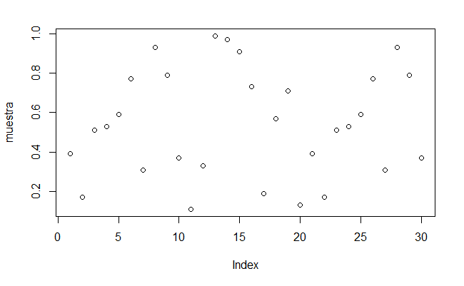

```r
#Diagrama de dispersión
plot(muestra)
```

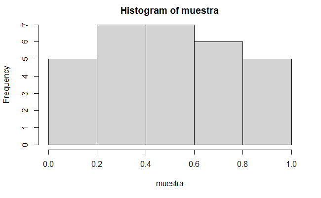

```r
#Histograma
hist(muestra)
```

Según la teoría de los grandes números para que se aproxime y sea un buen indicador de una muestra de variables aleatorias.

tiene que aproximarse a :

$$\ media = \mu = \frac{\sum_{i=1}^N \ x_{i}}{N} = \ 1/2 = 0.5$$

```r
mean(muestra)
```

```
[1] 0.5453333
```

Varianza $\sigma$

```r
var(muestra)
```

```
[1] 0.07356368
```

### 3) Constrastes de bondad de ajuste

Se necesita para verificar si las observaciones obtenidas de la distribución son realmente de una muestra aleatoria simple de U(0,1).

### Planteamiento del problema

Sea $\ (\ U_{1},...,U_{n})$ v.a.i.i.d según U, con función de distribución $\ F(x)$ no conocida y $\ F_{0}(x)$ contraste conocido

#### Planteamiento de la Hipótesis

$$\ H_{0} : \ F(x) = \ F_{0}(x) \\ \ H_{1} : \ F(x) \neq \ F_{0}(x)$$
donde
$$\ F_{0}(x)$$
es la función de distribución de una variable aleatoria U(0,1), por tanto:

$$f(x)=\left\{
\begin{array}{ll}
0 & \text{si }x\leq 0 \\
x & \text{si } 0 \leq\ x\leq 1 \\
1 & \text{si }x\geq 1
\end{array}
\right.$$

Se aplica varios procedimientos de contraste pero los mas usados son el de Kolmogorov-Smirnov, no parametrico y el de la $\chi^{2}$ , relacionado con el contraste de razón de verosimilidades de la multinomial.